# Leptospira_Demographic

Rachel Xu

6/3/2020

### Demographic Analysis for Leptopsira Isolates with Collection Date

- **PATRIC** database has collection dates available for some isolates that were missing in NCBI (353)
- **NCBI** has Raw reads records with collection dates but w/o assemblies that were self-assembled (36)

```r
library(dplyr)
library(tidyverse)
library(lubridate)
```

```r
library(ggplot2)
```

```r
path = "/Users/rx32940/Dropbox/5.Rachel-projects/Phylogeography/Dated_Assemblies/"
setwd(path)
```

### 353 NCBI downloaded Assemblies with metadata in PATRIC

- Change all the dates into the same format
- merge meatdata from PATRIC with NCBI biosample accessions ID’s
- if the collection.Date only has “year”, change the date to “year-01-01”
- if only has “year” and “month”, change the date to “year-month-01”
- format: “year-month-date”

```r
# biosample_353 <- read.csv(paste(path,"with_asm_353_acc.txt",sep=""), header=FALSE, sep="\n")
# patric_metadata <- read.csv(paste(path,"PATRIC_WGS_dated_353.csv",sep=""), header = TRUE)
#
# colnames(biosample_353) <- "BioSample.Accession"
#
# metadata_353 <- left_join(biosample_353, patric_metadata, by="BioSample.Accession")
#
# # if Dates in Collection.Date contains "_", new col value in this row stays, elses add "-01-01"
# metadata_353 %<>% select(-c("Genome.ID","Organism.Name","NCBI.Taxon.ID","MLST","Isolation.Comments",'Sequencing.Platform','Assembly.Method','Isolation.Country','Additional.Metadata','Genome.Quality.Flags', 'Genome.Quality',"RefSeq.Accessions","Sequencing.Status","SRA.Accession","GenBank.Accessions","X")) %>%
#   mutate(Collection.Date.Edited = paste(Collection.Date,"-01-01",sep = ""))

# write_csv(metadata_353,paste(path,"metadata_353_edited.csv",sep="")) # manually change dates into the same format
```

### 389 NCBI Biosample database Leptospria Isolate Metadata (Collection Date)

- the table was extracted from xml downloaded with list of biosample accessions with batch entrez
- script for xml extraction in get_dated_asm.ipynb
- xml: `/Users/rx32940/Dropbox/5.Rachel-projects/Phylogeography/Dated_Assemblies/dated_biosample_389_metadata.xml`

```r
# metadata_ncbi_389 <- read.csv(paste(path,"ncbi_biosample_metadata_389.csv",sep=""))
# merged_ncbi_patric <- full_join(metadata_353,metadata_ncbi_389, by=c("BioSample.Accession"))
# write_csv(merged_ncbi_patric,paste(path,"metadata_389_merged_edited.csv",sep="")) # manually change dates into the same format
```

### START FROM THIS CELL: Format the collection date into a Date object with library(lubridate)

- Read Formatted Date saved from analysis above- DO NOT CHANGE PREVIOUS CELLS"
- add “-01-01” to end of all collection date
- write the df to a csv
- manually reformatted all the collection dates

```r
# edited_date_389 <- read.csv(paste(path,"metadata_389_merged_edited.csv",sep="")) %>%
#   mutate(Collection.Date.Formatted = paste(as.character(Collection.Date.x),"-01-01",sep = ""))
# edited_date_389$Collection.Date.Formatted
# write_csv(edited_date_389,paste(path,"metadata_389_merged_edited.csv",sep="")) # manually reformatted the dates

# read the reformatted date table
# edited_date_389 <- read.csv(paste(path,"metadata_389_merged_edited.csv",sep=""))
#edited_date_389$Collection.Date.Formatted
# edited_date_389$Collection.Date.Formatted <- ymd(edited_date_389$Collection.Date.Formatted)
#
# edited_date_389$Year <- year(edited_date_389$Collection.Date.Formatted)
load("metadata_389_merged_edited.RData")
earliest <- min(edited_date_389$Collection.Date.Formatted) # 1915-01-01
latest <- max(edited_date_389$Collection.Date.Formatted) # 2017-10-30

# save(edited_date_389,file=paste(path,"metadata_389_merged_edited.RData",sep="")) # save in RData to keep the date format (excel keep chaning formats)
```

### Distribution base on the year

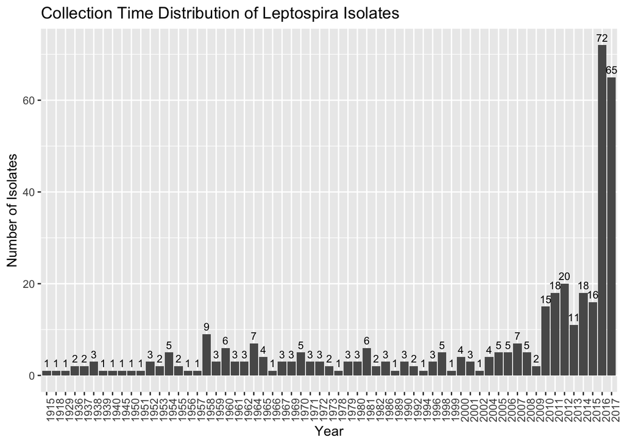

```r
ggplot(edited_date_389,aes(x=as.character(Year))) +
  geom_bar() +
  geom_text(stat="count",aes(label=..count..,vjust=-0.5,degree=25),size=3) +
  theme(axis.text.x=element_text(angle=90)) +
  labs(x="Year",y="Number of Isolates",title="Collection Time Distribution of Leptospira Isolates")
```

# Reformat the Geographical locations based on Country and regions

```r
# extract country out of geographical locations
edited_date_389 <- edited_date_389 %>% mutate(country = ifelse(grepl(":",Geographic.Location.x,fixed=TRUE),str_trim(strsplit(Geographic.Location.x,":")[[1]][1]), ifelse(grepl(",",Geographic.Location.x,fixed=TRUE),str_trim(strsplit(Geographic.Location.x,":")[[1]][2]),Geographic.Location.x)))

# replace empty cells with Unknown for plotting
edited_date_389$country <- ifelse(edited_date_389$country == "", "Unknown", edited_date_389$country)
edited_date_389$country <- ifelse(edited_date_389$country == "Sao Paulo", "Brazil", edited_date_389$country)
edited_date_389$country <- ifelse((edited_date_389$country == "Zaire") | (edited_date_389$country == "Belgian Congo"), "Congo democratic", edited_date_389$country)
unique(edited_date_389$country) # 30 -2 (San paulo & Zire-Belgium Congo -> Congo Democratic)
```

```
##  [1] "Brazil"                "Mayotte"               "Panama"
##  [4] "China"                 "Malaysia"              "Saint Kitts and Nevis"
##  [7] "Netherlands"           "New Caledonia"         "United States"
## [10] "Australia"             "Trinidad and Tobago"   "Indonesia"
## [13] "Denmark"               "Congo democratic"      "Unknown"
## [16] "France"                "Sri Lanka"             "Japan"
## [19] "Thailand"              "Nicaragua"             "Ecuador"
## [22] "Peru"                  "Russia"                "Guadeloupe"
## [25] "Algeria"               "Colombia"              "French Polynesia"
## [28] "Italy"
```

```r
# write unique countries into a file to manually find their Global Burden of Disease District
# write.table(unique(edited_date_389$country),paste(path,"countries_list_dated_30.txt",sep = ""),eol = "\n",row.names=FALSE,col.names=FALSE,quote = FALSE)
# save(edited_date_389,file=paste(path,"metadata_389_merged_edited.RData",sep=""))
```

# Plot base on the Geographical location of each country

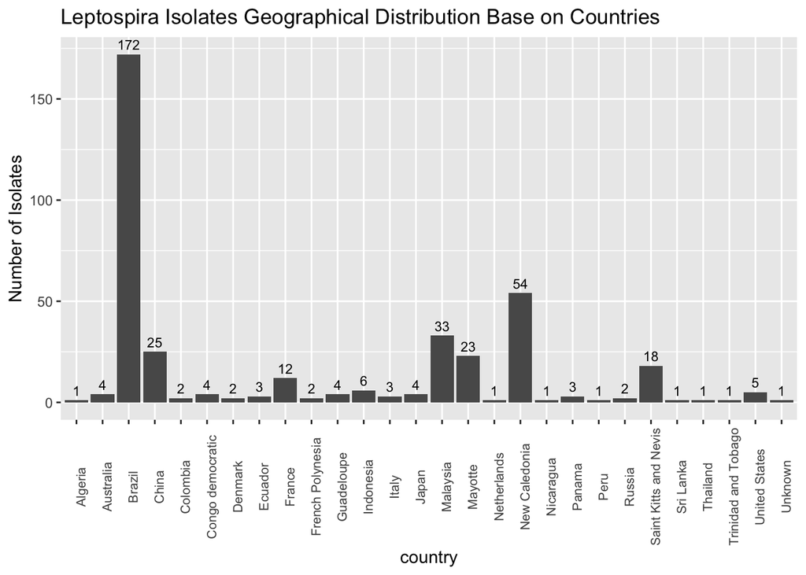

```r
ggplot(edited_date_389,aes(x=country))+
  geom_bar()+
  theme(axis.text.x=element_text(angle=90,size=8))+
  labs(title="Leptospira Isolates Geographical Distribution Base on Countries", y="Number of Isolates") + geom_text(stat="count",aes(label=..count..,vjust=-0.5,degree=25),size=3)
```

### add GBD regions and super regions to the dataframe for plotting

- source of **GBD region** based on this article: https://aasldpubs.onlinelibrary.wiley.com/doi/full/10.1002/hep.26141
- source of **GBD super region**: https://atlas.iapb.org/wp-content/uploads/GBD-21-Regions-Map.pdf

```r
GBD <- read.csv(paste(path,"countries_GBD_regions.csv",sep=""))
# GBD
edited_date_389 <- left_join(edited_date_389,GBD, by="country")
length(edited_date_389$country)
```

```
## [1] 389
```

### Plot base on GBD Distribution

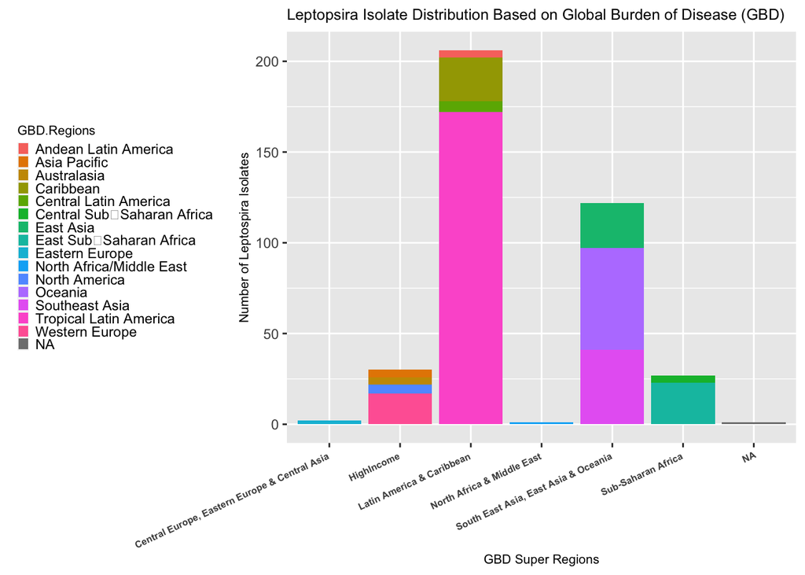

```r
ggplot(edited_date_389) +
  geom_bar(aes(x=GBD.Super.Regions,fill=GBD.Regions))+
  theme(axis.text.x=element_text(angle=25,size=6,hjust=1,face="bold"), legend.position = "left",legend.key.size =  unit(0.5,"line"),title=element_text(size=8))+
  labs(title="Leptopsira Isolate Distribution Based on Global Burden of Disease (GBD)",x="GBD Super Regions",y="Number of Leptospira Isolates")
```